# Powerlifting Analysis on IPF Tournaments

Powerlifting is a strength-based sport where athletes compete by performing three compound movements: squat, bench press, and deadlift. Each of these lifts can be loaded incredibly heavy and each challenge different muscle groups. Athletes train to lift the heaviest weight possible in all three events in a single day in order to achieve the high possible total. Powerlifting tournaments are hosted at different levels (locally, state, regionally, nationally, and internationally) and split into different divisions based on the athletes age, sex, and weight to ensure a balanced competition. These competitions attract athletes from all ranges of age groups with different amounts of experience.

In this project we look at data for powerlifting tournaments. We will look specifically at tournaments hosted by the International Powerlifting Federation (IPF) as they are one of the largest organizations resposible for hosting quality, high-standard competitions internationally. They do this by following a technical rulebook which is enforced by all of their affiliate organizers (**[technical rulebook](https://www.powerlifting.sport/rules/codes/info/technical-rules)**).

The dataset we will be using comes from the Openpowerlifting Data Service. They are a community of powerlifters who scrape the internet for tournament information and append it to their database. They provide a great service to the powerlifting community by creating a permanent archive of the world's powerlifting data and providing it in convenient formats. In addition to the datasets, they have clear documentation on their table, columns, and values which makes it a perfect dataset for analysis.

On the Openpowerlifting site, we obtain the data for powerlifting tournaments by the IPF and affiliates only. This is to ensure data integrity and accuracy of our dataset and thus our analysis. The main purpose of these tournaments is to determine who the strongest athlete is. We will explore the data to determine what factors contribute to determining an athlete's strength and what is required of an athlete in order to win a tournament. Some examples of athlete attributes which play a major role are their age, sex, and weight. We will explore how much each of the athlete's events (squat, deadlift, and bench press) contribute towards their total strength. Next, we will explore the probability or requirements for an athlete to potentially win a tournament. Finally, we will use regression algorithms to predict the strength levels of athletes.

## Data Collection

We use Python3 and libraries such as pandas, matplotlib and scikit-learn to perform our analysis and create our models.

- Pandas is useful to store datasets, filtering data, and performing search queries.
- Matplotlib is our main tool to create visualizations in Python
- Scikit-Learn contains models for regression models we want to implement and error metrics to measure accuracy

```python
import pandas as pd
import matplotlib.pyplot as plt
from sklearn.neighbors import KNeighborsRegressor
from sklearn.tree import DecisionTreeRegressor
from sklearn.model_selection import train_test_split, KFold, cross_val_score, cross_validate
from sklearn.metrics import mean_squared_error, mean_absolute_error
```

### Acquiring the Data

The data can be downloaded from the OpenPowerlifting site **[here](https://openpowerlifting.gitlab.io/opl-csv/)**. On the site, we can follow the sidebar to "Bulk CSV Downloads" and select which dataset we want to use. There is a complete dataset containing information from all tournaments and another which only contains information about tournaments hosted by the IPF or its affiliates. Additionally, there is documentation for the columns of the dataset if more information is desired. For our analysis, we will use the dataset with only IPF and affiliate information to avoid unnecessary work

```python
data = pd.read_csv('openipf.csv', low_memory = False)
```

Now that we have our data, let's look at what columns we have to work with.

```python
data.columns
```

```
Index(['Name', 'Sex', 'Event', 'Equipment', 'Age', 'AgeClass',
       'BirthYearClass', 'Division', 'BodyweightKg', 'WeightClassKg',
       'Squat1Kg', 'Squat2Kg', 'Squat3Kg', 'Squat4Kg', 'Best3SquatKg',
       'Bench1Kg', 'Bench2Kg', 'Bench3Kg', 'Bench4Kg', 'Best3BenchKg',
       'Deadlift1Kg', 'Deadlift2Kg', 'Deadlift3Kg', 'Deadlift4Kg',
       'Best3DeadliftKg', 'TotalKg', 'Place', 'Dots', 'Wilks', 'Glossbrenner',
       'Goodlift', 'Tested', 'Country', 'State', 'Federation',
       'ParentFederation', 'Date', 'MeetCountry', 'MeetState', 'MeetTown',
       'MeetName'],
      dtype='object')
```

In this dataset, we will focus primarily on these columns:

- Sex - Sex category athlete competed in
- Event - Tells us which lifts the athlete competed in [S] - Squat, [B] - Bench, [D] - Deadlift (or some permutation of the three)
- Age - Athlete's age in Kg
- AgeClass - What age range they are categorized as under IPF rules
- Division - Name of their division (based on age and body weight)
- BodyweightKg - Athlete's weight in Kg
- WeightClassKg - Athlete's weight class in Kg
- Best3SquatKg, Best3BenchKg, Best3DeadliftKg - Their heaviest successful lift out of three attempts
- TotalKg - The total of their heaviest three successful lifts (empty if one of three lifts failed). **This will also be our main indicator of an athlete's strength.**
- Date

### Data Cleansing

Now that we have our data, let's begin cleaning. Since we know our data is merged from different IPF affiliates, there will be some inconsistencies as different affiliates can split divisions by different age or weight ranges. As per the IPF technical rule book, athletes are first divided by sex, then age group, and finally weight. These columns are all important for identifying relationships and trends between athletes, we will remove any data that has null values for columns:

- Age
- Sex
- BodyWeightKg
- TotalKg

```python
data = data.dropna(subset = ['Age', 'Sex', 'BodyweightKg', 'TotalKg'])
```

We will also remove any rows where the athlete's age is not recorded (as 0), recorded correctly, or athlete's who didn't qualify to compete. IPF tournaments begin at age 14 so we will filter anything beneath that.

```python
data = data[data['Age'] >= 14]
```

Next, we inspect the Sex column in our data.

```python
data.Sex.unique()
```

```
array(['F', 'M', 'Mx'], dtype=object)
```

We see that IPF tournaments include a gender-neutral term for athletes. Let's look at the data to get a better understanding of how large this group is.

```python
data_Mx = data[data['Sex'] == 'Mx']
data_Mx
```

|  | Name | Sex | Event | Equipment | Age | AgeClass | BirthYearClass | Division | BodyweightKg | WeightClassKg | ... | Tested | Country | State | Federation | ParentFederation | Date | MeetCountry | MeetState | MeetTown | MeetName |
| --- | --- | --- | --- | --- | --- | --- | --- | --- | --- | --- | --- | --- | --- | --- | --- | --- | --- | --- | --- | --- | --- |
| 158532 | Emilia McConnell | Mx | SBD | Raw | 24.5 | 24-34 | 24-39 | XR-O | 87.00 | 90 | ... | Yes | USA | MI | USAPL | IPF | 2021-10-16 | USA | MI | NaN | Michigan Rookie Rumble |
| 172850 | Elaine Bradley | Mx | SBD | Raw | 23.5 | 24-34 | 24-39 | XR-O | 88.00 | 84+ | ... | Yes | USA | GA | USAPL | IPF | 2020-11-07 | USA | GA | NaN | Viking Strength Sports |
| 187615 | Angel Flores #1 | Mx | SBD | Raw | 21.5 | 20-23 | 19-23 | XR-Jr | 92.42 | 100 | ... | Yes | USA | TX | USAPL | IPF | 2021-05-01 | USA | TX | NaN | Iron Triathlon |
| 249940 | Andrew Pond | Mx | D | Raw | 31.5 | 24-34 | 24-39 | XR-O | 103.80 | 110 | ... | Yes | USA | WI | USAPL | IPF | 2021-09-11 | USA | WI | NaN | Stars And Stripes Open |
| 259515 | Angel Flores #1 | Mx | SBD | Raw | 21.5 | 20-23 | 19-23 | XR-Jr | 93.60 | 100 | ... | Yes | USA | TX | USAPL | IPF | 2021-10-23 | USA | TX | NaN | Austin Fall Frenzy |
| 262311 | Elaine Bradley | Mx | SBD | Raw | 24.5 | 24-34 | 24-39 | XR-O | 81.10 | 82.5 | ... | Yes | USA | GA | USAPL | IPF | 2021-04-24 | USA | GA | NaN | Georgia State Championships |

6 rows × 41 columns

As the IPF does not yet host a tournament for gender-neutral individuals and there is not enough information in the dataset to determine which category these athletes competed in, they will be grouped with the Male categories for the majority of the analysis. However, later when we create our regression model, this can be a valuable piece of information.

Next, we will remove the AgeClassKg and WeightClassKg columns from the dataset to align better with IPF standard ranges. We will also remove Divisions as they are susceptible to this as well.

```python
data = data.drop('WeightClassKg', axis = 'columns')
data = data.drop('AgeClass', axis = 'columns')
data = data.drop('Division', axis = 'columns')
```

We now recreate these same classes using IPF standards. For males, their age class is split from

- Open, All age groups 14 and above
- Sub-Junior, day he reaches 14 to 18
- Junior, day he reaches 19 to 23
- Master I, day he reaches 40 to 49
- Master II, day he reaches 50 to 59
- Master III, day he reaches 60 to 69
- Master IV, 70 and upwards

For females, similar divisions

- Open, All age groups 14 and above
- Sub-Junior, day he reaches 14 to 18
- Junior, day he reaches 19 to 23
- Master I, day he reaches 40 to 49
- Master II, day he reaches 50 to 59
- Master III, day he reaches 60 to 69
- Master IV, 70 and upwards

And for Mx, we will assume the same ranges.

- Open, All age groups 14 and above
- Sub-Junior, day he reaches 14 to 18
- Junior, day he reaches 19 to 23
- Master I, day he reaches 40 to 49
- Master II, day he reaches 50 to 59
- Master III, day he reaches 60 to 69
- Master IV, 70 and upwards

```python
AgeClass = []
Division = []
for index, row in data.iterrows():
    if row['Age'] >= 14 and row['Age'] <= 18:
        AgeClass.append('14-18')
        Division.append('Sub-Junior')
    elif row['Age'] >= 19 and row['Age'] <= 23:
        AgeClass.append('19-23')
        Division.append('Junior')
    elif row['Age'] >= 40 and row['Age'] <= 49:
        AgeClass.append('40-49')
        Division.append('Master I')
    elif row['Age'] >= 50 and row['Age'] <= 59:
        AgeClass.append('50-59')
        Division.append('Master II')
    elif row['Age'] >= 60 and row['Age'] <= 69:
        AgeClass.append('60-69')
        Division.append('Master III')
    elif row['Age'] >= 70 and row['Age'] <= 79:
        AgeClass.append('70-79')
        Division.append('Master IV')
    else:
        AgeClass.append('Any')
        Division.append('Open')
data['AgeClass'] = AgeClass
data['Division'] = Division
```

Now we follow a similar procedure for creating the WeightClassKg column except now there exists differences in the weight range between male and female athletes. As there is only 6 athletes under the Mx category, we will just categorize them in similar ranges as the male athletes. The value in the new WeightClassKg column will be the upper limit of the weight class. For the final class, the no upper bound class will be denoted as 1000.

```python
WeightClassKg = []
for index, row in data.iterrows():
    if row['Sex'] == 'F':
        if row['BodyweightKg'] < 43 and (row['Division'] == 'Sub-Junior' or row['Division'] == 'Junior'):
            WeightClassKg.append(43)
        elif row['BodyweightKg'] <= 47:
            WeightClassKg.append(47)
        elif row['BodyweightKg'] <= 52.0:
            WeightClassKg.append(52)
        elif row['BodyweightKg'] <= 57.0:
            WeightClassKg.append(57)
        elif row['BodyweightKg'] <= 63.0:
            WeightClassKg.append(63)
        elif row['BodyweightKg'] <= 69.0:
            WeightClassKg.append(69)
        elif row['BodyweightKg'] <= 76.0:
            WeightClassKg.append(76)
        elif row['BodyweightKg'] <= 84.0:
            WeightClassKg.append(84)
        else:
            WeightClassKg.append(1000)
    else:
        if row['BodyweightKg'] < 53 and (row['Division'] == 'Sub-Junior' or row['Division'] == 'Junior'):
            WeightClassKg.append(53)
        elif row['BodyweightKg'] <= 59:
            WeightClassKg.append(59)
        elif row['BodyweightKg'] <= 66.0:
            WeightClassKg.append(66)
        elif row['BodyweightKg'] <= 74.0:
            WeightClassKg.append(74)
        elif row['BodyweightKg'] <= 83.0:
            WeightClassKg.append(83)
        elif row['BodyweightKg'] <= 93.0:
            WeightClassKg.append(93)
        elif row['BodyweightKg'] <= 105.0:
            WeightClassKg.append(105)
        elif row['BodyweightKg'] <= 120.0:
            WeightClassKg.append(120)
        else:
            WeightClassKg.append(1000)
data['WeightClassKg'] = WeightClassKg
```

## Exploratory Analysis

Now that we've categorized the athlete's division by IPF standards, we can begin exploring the data. As we've seen, the IPF goes to great lengths to create balanced divisions in order for athlete's to have a fair competition. This is done by accounting for the athlete's age, weight, and sex. We are curious as to how strong the relationship between these factors have on an athlete's strength individually or in some combination.

### Graphing Strength vs. Body Weight

Let's look at the relationship between an athlete's body weight and strength. Strength will be measured through the TotalKG columns for each athlete. This is the total amount of weight an athlete moved in all three events combined. We will only look at athletes who lifted in all three events. We know an athlete performs all three events if the value in 'Event' is equal to 'SBD'.

```python
tempSBD = data[data['Event'] == 'SBD']
```

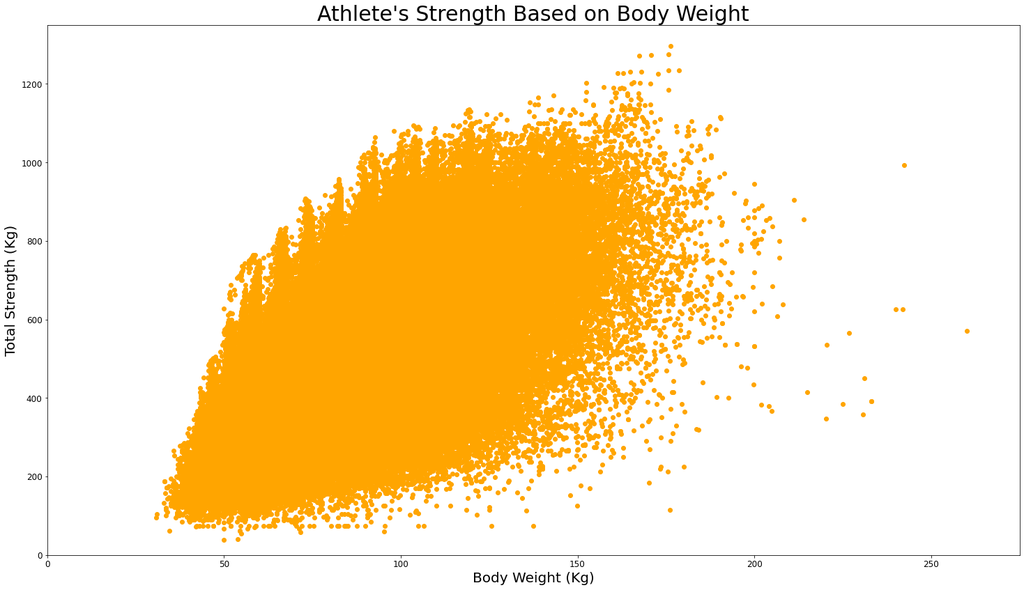

```python
figure1, ax = plt.subplots(figsize = (25, 14))
ax.scatter(tempSBD['BodyweightKg'], tempSBD['TotalKg'], c = 'orange')
ax.set_xlabel('Body Weight (Kg)', fontsize = 20)
ax.set_ylabel('Total Strength (Kg)', fontsize = 20)
ax.set_title("Athlete's Strength Based on Body Weight", fontsize = 30)
plt.xlim([0,275])
plt.ylim([0,1350])
plt.xticks(fontsize = 12)
plt.yticks(fontsize = 12)
plt.show()
```

There is large variability between an athlete's strength and body weight. The two variables do seem to share a positive linear relationship where as the body weight of the athlete increases, so does their total strength. However, there are some visible outliers where athlete's at a higher body weight (~200 Kg) don't entirely perform better than those at a lower body weight. It makes sense that the IPF would want to break athlete's into separate weight categories as there is a clear advantage for heavier athletes. We have a lot of data so let's split the athlete's by sex (where Mx athlete's will be combined with the male athlete's data) to see if the same trend is true across both groups.

```python
temp_F = tempSBD[tempSBD['Sex'] == 'F']
temp_M = tempSBD[tempSBD['Sex'] != 'F']
```

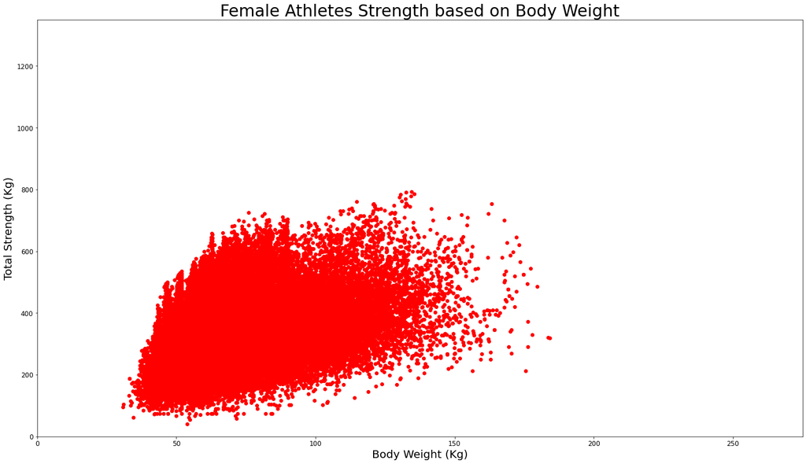

```python
figure2, ax = plt.subplots(figsize = (25, 14))
ax.scatter(temp_F['BodyweightKg'], temp_F['TotalKg'], c = 'r')
ax.set_xlabel('Body Weight (Kg)', fontsize = 20)
ax.set_ylabel('Total Strength (Kg)', fontsize = 20)
plt.xlim([0,275])
plt.ylim([0,1350])
plt.xticks(fontsize = 12)
plt.yticks(fontsize = 12)
ax.set_title("Female Athletes Strength based on Body Weight", fontsize = 30)
plt.show()
```

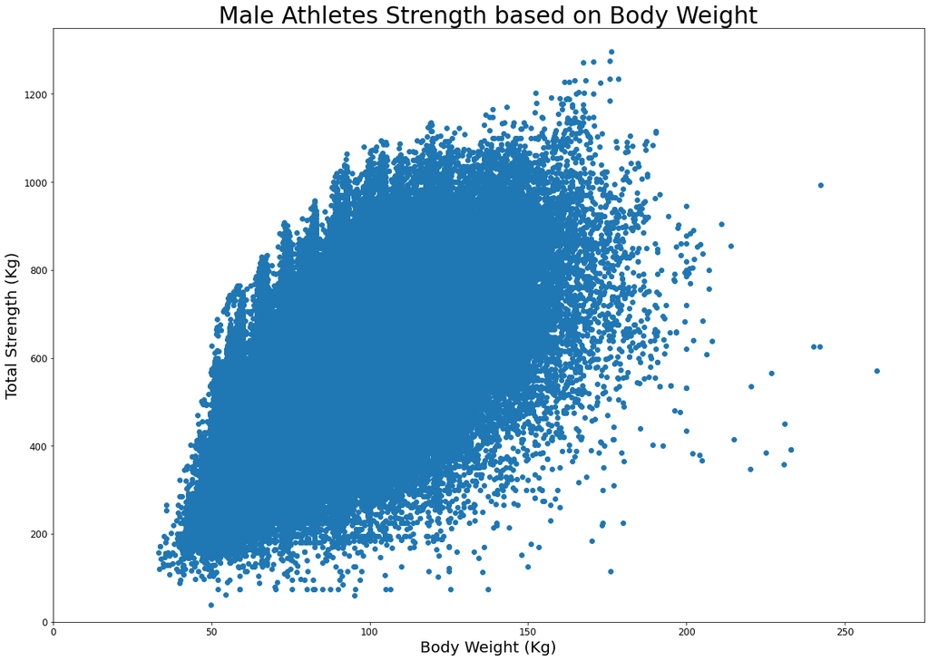

```python
figure3, ax = plt.subplots(figsize = (20, 14))
ax.scatter(temp_M['BodyweightKg'], temp_M['TotalKg'])
ax.set_xlabel('Body Weight (Kg)', fontsize = 20)
ax.set_ylabel('Total Strength (Kg)', fontsize = 20)
plt.xlim([0,275])
plt.ylim([0,1350])
plt.xticks(fontsize = 12)
plt.yticks(fontsize = 12)
ax.set_title("Male Athletes Strength based on Body Weight", fontsize = 30)
plt.show()
```

By keeping the same axis, we see that female and male athletes have a similar relationship between weight and strength. It seems that males have a larger variability of strength at around the same body weight than female athletes. The slope at which strength increases by body weight also seems larger for males.

### Graphing Strength vs. Age

Now we look at the relationship between an athlete's age and lifting strength. We continue to use TotalKg as our measure of strength and split the data into male and female athlete's in order to identify any differences.

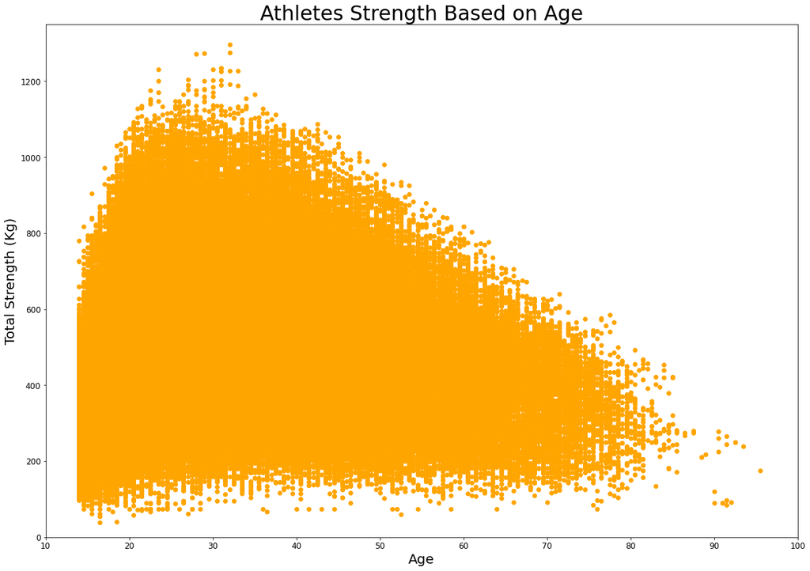

```python
figure4, ax = plt.subplots(figsize = (20, 14))
ax.scatter(tempSBD['Age'], tempSBD['TotalKg'], c = 'orange')
ax.set_xlabel('Age', fontsize = 20)
ax.set_ylabel('Total Strength (Kg)', fontsize = 20)
plt.xlim([10,100])
plt.ylim([0,1350])
plt.xticks(fontsize = 12)
plt.yticks(fontsize = 12)
ax.set_title("Athletes Strength Based on Age", fontsize = 30)
plt.show()
```

The spread for this relationship is very different than the relationhip for body weight. The data sees a slight increase at the beginning but then turns into a clear descent starting around age 35. There is definetely a larger variability between athletes of the same age and their strength. Once again we will split by sex to identify more trends. We can also use this plot to see that the popularity of powerlifting is strong through a lot of age groups. It seems to be least popular when you reach age ~75.

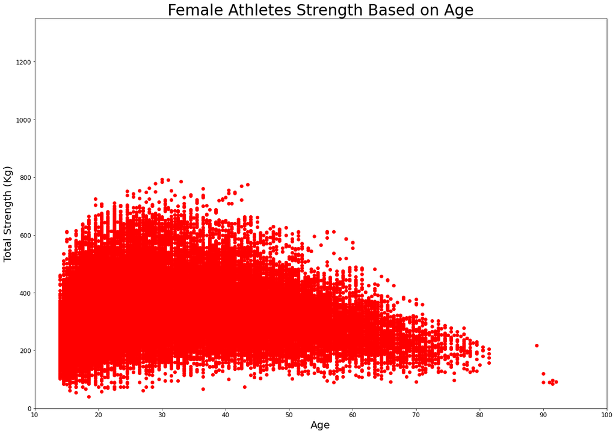

```python
figure5, ax = plt.subplots(figsize = (20, 14))
ax.scatter(temp_F['Age'], temp_F['TotalKg'], c = 'red')
ax.set_xlabel('Age', fontsize = 20)
ax.set_ylabel('Total Strength (Kg)', fontsize = 20)
plt.xlim([10,100])
plt.ylim([0,1350])
plt.xticks(fontsize = 12)
plt.yticks(fontsize = 12)
ax.set_title("Female Athletes Strength Based on Age", fontsize = 30)
plt.show()
```

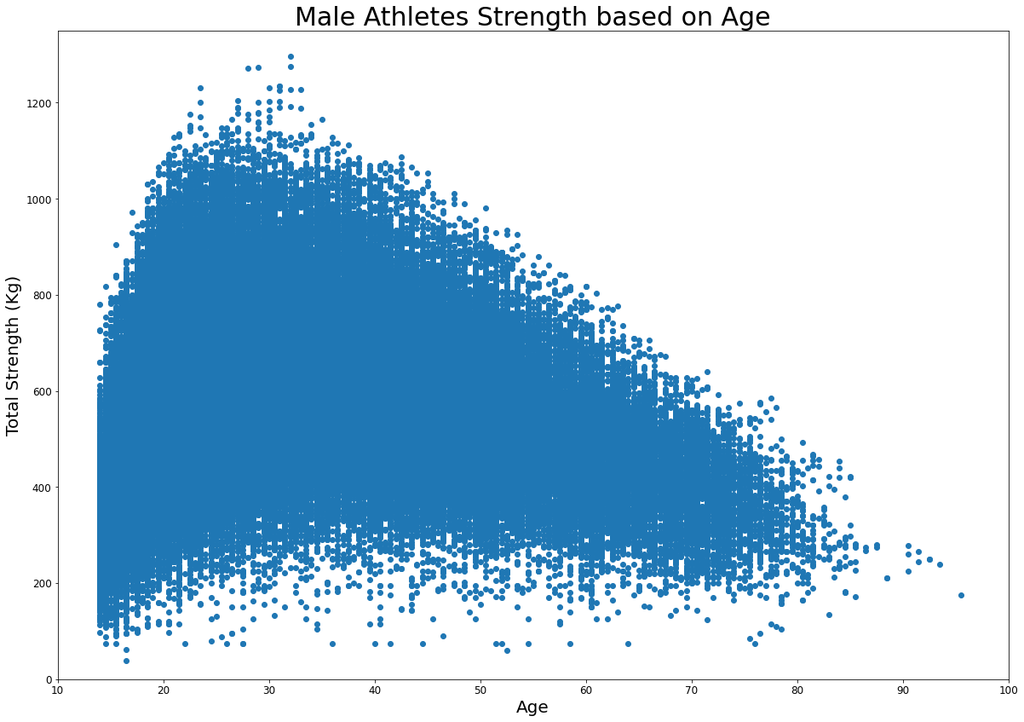

```python
figure6, ax = plt.subplots(figsize = (20, 14))
ax.scatter(temp_M['Age'], temp_M['TotalKg'])
ax.set_xlabel('Age', fontsize = 20)
ax.set_ylabel('Total Strength (Kg)', fontsize = 20)
plt.xlim([10,100])
plt.ylim([0,1350])
plt.xticks(fontsize = 12)
plt.yticks(fontsize = 12)
ax.set_title("Male Athletes Strength based on Age", fontsize = 30)
plt.show()
```

There is still a negative linear relationship between male and female athletes at around age 30. However, it does seem that the female athletes strength decreases less over age than that of male athletes. There are also more female outliers who surpass others athletes in strength at the same age.

### Comparing Event's Contribution to Total Lift Based on Athlete's Age and Weight Category

Now we want to look at how much each event (Squat, Bench, and Deadlift) contributes towards the total lifting weight. We want to see which lifts are an athlete's strongest and possibly what athletes should focus on to maximize their total lift potential. We will look at the average strength between each age and weight group.

To perform our analysis, we must split the athlete data by their sex, age, and weight. We will use the same temp_F and temp_M data as earlier to only look at athlete's who participated in all three events (since temp_F and temp_M both only contain athlete information who participated in all three events). Then, we will sort the datasets by age class then weight class (to make our presentation nicer). Finally, we will group the data by all possible age and weight classes to acquire mean values for the best of each three events and their total strength.

```python
temp_F = temp_F.sort_values(by = ['AgeClass', 'WeightClassKg'])
```

```python
temp_M = temp_M.sort_values(by = ['AgeClass', 'WeightClassKg'])
```

```python
categories_F = temp_F.groupby(by = ['AgeClass', 'WeightClassKg']).mean()
```

```python
categories_M = temp_M.groupby(by = ['AgeClass', 'WeightClassKg']).mean()
```

Now we create our categories for each combination of age and weight class. These will be useful for identifying our bar in the chart.

```python
groups = [ageclass + ' ' + str(weightclass) for ageclass in temp_F['AgeClass'].unique() for weightclass in temp_F['WeightClassKg'].unique()]
groups.remove('Any 43')
groups.remove('40-49 43')
groups.remove('50-59 43')
groups.remove('60-69 43')
groups.remove('70-79 43')
```

[figure not shown]

```python
figure7, ax = plt.subplots(figsize = (35, 15))
b1 = ax.bar(groups, categories_F['Best3DeadliftKg'], label = 'Deadlift (Kg)')
b2 = ax.bar(groups, categories_F['Best3SquatKg'], label = 'Squat (Kg)', bottom = categories_F['Best3DeadliftKg'])
b3 = ax.bar(groups, categories_F['Best3BenchKg'], label = 'Bench Press (Kg)', bottom = categories_F['Best3SquatKg'])
ax.set_xlabel('Division Based on Age Group and Weight Group', fontsize =20)
ax.set_ylabel('Total (Kg)', fontsize = 20)
ax.set_title('Event Contribution Towards Total Strength for Female Athletes', fontsize = 30)
ax.legend(fontsize = 12)
plt.xticks(rotation=45, fontsize = 12)
plt.yticks(fontsize = 12)
plt.ylim([0,350])
ax.bar_label(b1, labels = (round(categories_F['Best3DeadliftKg']/categories_F['TotalKg'] * 100)), label_type = 'center')
ax.bar_label(b2, labels = (round(categories_F['Best3SquatKg']/categories_F['TotalKg'] * 100)), label_type = 'center', padding = 30)
ax.bar_label(b3, labels = (round(categories_F['Best3BenchKg']/categories_F['TotalKg'] * 100)), label_type = 'center')

plt.grid()
plt.show()
```

Now we do a similar process/analysis on the male athletes

```python
groups = [ageclass + ' ' + str(weightclass) for ageclass in temp_M['AgeClass'].unique() for weightclass in temp_M['WeightClassKg'].unique()]
groups.remove('Any 53')
groups.remove('40-49 53')
groups.remove('50-59 53')
groups.remove('60-69 53')
groups.remove('70-79 53')
```

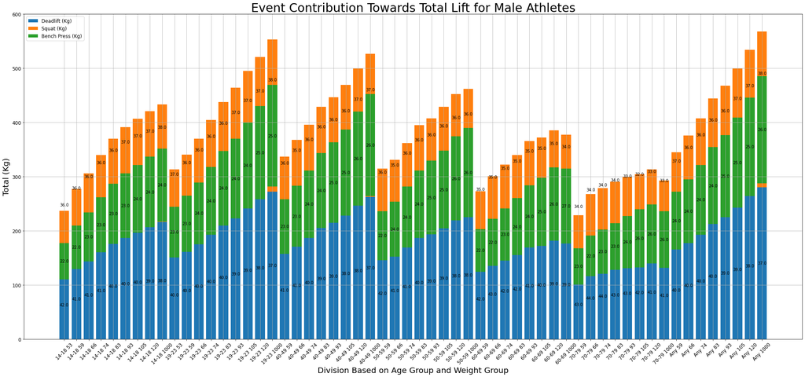

```python
figure8, ax = plt.subplots(figsize = (35, 15))
b1 = ax.bar(groups, categories_M['Best3DeadliftKg'], label = 'Deadlift (Kg)')
b2 = ax.bar(groups, categories_M['Best3SquatKg'], label = 'Squat (Kg)', bottom = categories_M['Best3DeadliftKg'])
b3 = ax.bar(groups, categories_M['Best3BenchKg'], label = 'Bench Press (Kg)', bottom = categories_M['Best3SquatKg'])
ax.set_xlabel('Division Based on Age Group and Weight Group', fontsize = 20)
ax.set_ylabel('Total (Kg)', fontsize = 20)
ax.set_title('Event Contribution Towards Total Lift for Male Athletes', fontsize = 30)
ax.legend(fontsize = 12)
plt.xticks(rotation=45, fontsize = 12)
plt.yticks(fontsize = 12)
plt.ylim([0,600])
ax.bar_label(b1, labels = (round(categories_M['Best3DeadliftKg']/categories_M['TotalKg'] * 100)), label_type = 'center')
ax.bar_label(b2, labels = (round(categories_M['Best3SquatKg']/categories_M['TotalKg'] * 100)), label_type = 'center', padding = 90)
ax.bar_label(b3, labels = (round(categories_M['Best3BenchKg']/categories_M['TotalKg'] * 100)), label_type = 'center')
plt.grid()
plt.show()
```

### How Strong Is a Winner?

Now that we've looked at the relationships between strength based on age, sex, and events, let's attempt to identify how strong an athlete must be to win a tournmanet. How much stronger an athlete has to be can be defined by comparing them to the average results of athlete's in their same age and weight group.

We must first identify the winners in our database. According to the documentation, column 'Place' records the place of the lifter in the given division at the end of the meet. We care solely about individuals who took first place so we will filter for that. We will the find the averages strength for the winners amongst their respective age and weight categories.

Let's filter for solely first place winners.

```python
winners = tempSBD[tempSBD['Place'] == '1']
```

Now we average all winners amongst themselves.

```python
grouped_winners = winners.groupby(by = ['Sex', 'AgeClass', 'WeightClassKg']).mean()
```

Now we look at the total average amongst the total population.

```python
grouped_total = tempSBD.groupby(by = ['Sex', 'AgeClass', 'WeightClassKg']).mean()
```

Finally, we calculate the difference between the two groups. Say we only care about age, body weight, best lift for each event, and the total.

```python
grouped_total = grouped_total[['Age', 'BodyweightKg', 'Best3SquatKg', 'Best3BenchKg', 'Best3DeadliftKg', 'TotalKg']]
grouped_winners = grouped_winners[['Age', 'BodyweightKg', 'Best3SquatKg', 'Best3BenchKg', 'Best3DeadliftKg', 'TotalKg']]
```

```python
diff = grouped_total.compare(grouped_winners)
```

Now that we have the two groups, we first look at the male athletes.

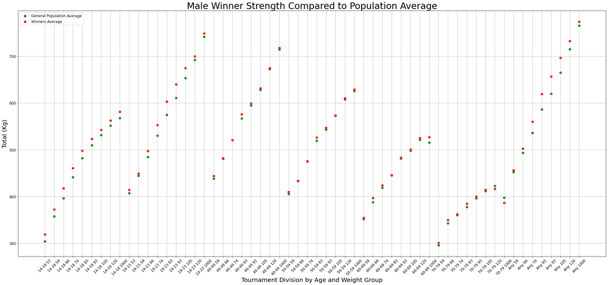

```python
figure9, ax = plt.subplots(figsize = (35, 15))
ax.scatter(groups, diff.loc['M' ,('TotalKg', 'self')], s = 50, c = 'g')
ax.scatter(groups, diff.loc['M', ('TotalKg', 'other')], s = 50, c = 'r')
ax.set_xlabel('Tournament Division by Age and Weight Group', size = 20)
ax.set_ylabel('Total (Kg)', size = 20)
ax.set_title('Male Winner Strength Compared to Population Average', size = 30)
ax.legend(['General Population Average', 'Winners Average'], fontsize = 12)
plt.xticks(rotation = 45, fontsize = 12)
plt.yticks(fontsize = 12)
plt.grid()
plt.show()
```

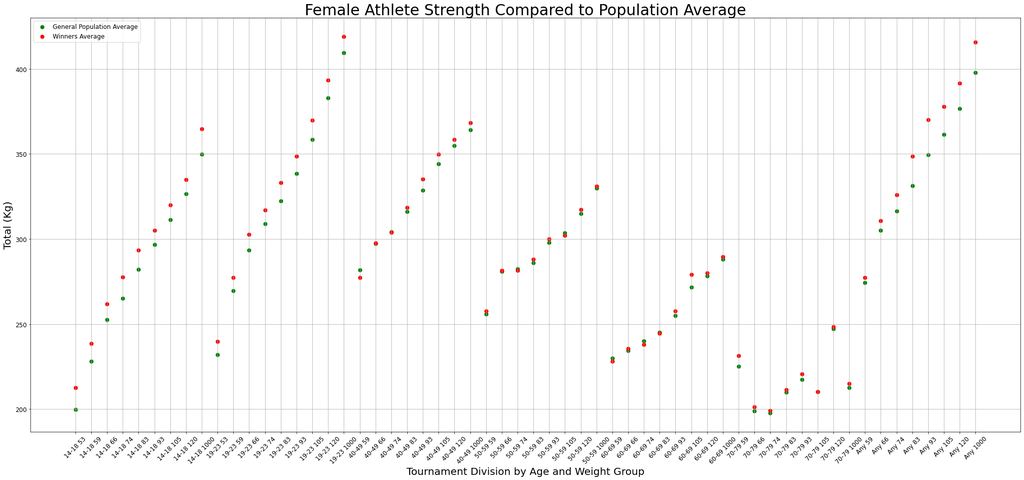

```python
figure10, ax = plt.subplots(figsize = (35, 15))
ax.scatter(groups, diff.loc['F' ,('TotalKg', 'self')], s = 50, c = 'g')
ax.scatter(groups, diff.loc['F', ('TotalKg', 'other')], s = 50, c = 'r')
ax.set_xlabel('Tournament Division by Age and Weight Group', size = 20)
ax.set_ylabel('Total (Kg)', size = 20)
ax.set_title('Female Athlete Strength Compared to Population Average', size = 30)
ax.legend(['General Population Average', 'Winners Average'], fontsize = 12, loc = 'upper left')
plt.xticks(rotation = 45, fontsize = 12)
plt.yticks(fontsize = 12)
plt.grid()
plt.show()
```

## Predicting Strength in Athlete's

We have seen now that through different combinations of categories, there is a significant relationship between an athletes body weight and the total amount of weight they can lift. Now, we will attempt to create a regression model which attempts to predict the amount of weight an athlete can lift based on their sex, age, and body weight. This model will calculate the expected total weight.

We will filter our data to contain only the columns we care about.

```python
lift_data = tempSBD[['Sex', 'Age', 'BodyweightKg', 'Best3SquatKg', 'Best3BenchKg', 'Best3DeadliftKg', 'TotalKg']]
```

Now that we have our lift data, we check to see if we have any categorical variables that require attention. Which there is, for column 'Sex' we have string variables 'M', 'F', and 'Mx'. This means we must one-hot encode the values in this column. One-hot encoding is a process which turns categorical variables into individual columns for each unique value using 1's and 0's to indicate their value. This allows our regression model to read and use the data.

```python
temp_onehot = pd.get_dummies(lift_data['Sex'])
```

```python
lift_data = lift_data.drop('Sex', axis = 1)
```

```python
lift_data = lift_data.join(temp_onehot)
```

We will create athlete_data with just the athlete's sex, age, and bodyweight. The we will use the TotalKg column as our target for prediction.

```python
athlete_data = lift_data[['M', 'F', 'Mx', 'Age', 'BodyweightKg']]
strength_data = lift_data[['TotalKg']]
```

Next, we will initialize our regression models. We will use two different models available on scikit, the k nearest neighbor model and a decision tree model. This is in order to compare the accuracy of models and make sure we are getting accurate results.

```python
neigh = KNeighborsRegressor(algorithm = 'kd_tree', n_neighbors = 5)
```

```python
dectree = DecisionTreeRegressor(random_state = 22)
```

In order to fit a model, we must split the data into training and test sets. This is done in order to teach the model what our expected result should look like and then validate those results with values whose results we already know, but that the model does not know.

```python
X_train, X_test, y_train, y_test = train_test_split(athlete_data, strength_data, test_size = 0.25, random_state = 22)
```

Now that we have our training data, we fit both models with it.

```python
neigh.fit(X_train, y_train)
dectree.fit(X_train, y_train)
```

```
DecisionTreeRegressor(random_state=22)
```

Now with both models trained, we can test it using our testing data.

```python
y_bykNN = neigh.predict(X_test)
y_bydectree = dectree.predict(X_test)
```

Our model has predicted the expected strength for these athletes, now what? In order to determine if our model is effective or not, we must compare it to our actual data. We use three major measurements to test for error and which ultimately tells us the effectiveness of our models. There are mean squared error (MSE), root mean squared error (RMSE), and mean absolute error (MAE).

Starting with MSE:

```python
kNN_MSE = mean_squared_error(y_bykNN, y_test)
tree_MSE = mean_squared_error(y_bydectree, y_test)
if abs(kNN_MSE) < abs(tree_MSE):
    print('kNN')
    print (kNN_MSE)
else:
    print('dectree')
    print(tree_MSE)
```

```
kNN
10448.633199618404
```

We see that our mean squared error is rather large. This is because MSE tends to amplify errors that are greatly off versus errors that are smaller. We can get a different interpretation from our other metrics

```python
kNN_RMSE = mean_squared_error(y_bykNN, y_test, squared = False)
tree_RMSE = mean_squared_error(y_bydectree, y_test, squared = False)
if abs(kNN_RMSE) < abs(tree_RMSE):
    print('kNN')
    print (kNN_RMSE)
else:
    print('dectree')
    print(tree_RMSE)
```

```
kNN
102.21855604350124
```

The root mean squared error does a similar calculation as the MSE except it provides it to us in a more readable form.

```python
kNN_MAE = mean_absolute_error(y_bykNN, y_test)
tree_MAE = mean_absolute_error(y_bydectree, y_test)
if abs(kNN_MAE) < abs(tree_MAE):
    print('kNN')
    print (kNN_MAE)
else:
    print('dectree')
    print(tree_MAE)
```

```
kNN
79.02081041951077
```

The mean absolute error gives us the actual different between the prediced and actual value. This mean that on average, our prediction is about 79 kg off. This is a big difference since that is equivalent to about ~ 175 lbs. This sort of error comes from outliers in our data from athletes who are far above the population.

We see that the error for our k nearest neighbor model has a lower error value across all our metrics. We will attempt to plot our results for the regression model.

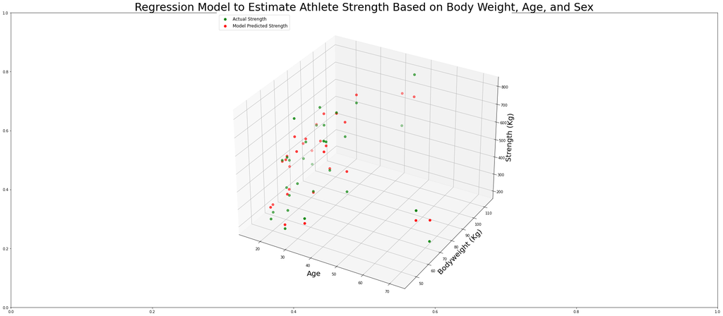

```python
figure11, ax = plt.subplots(figsize = (35, 15))
ax = plt.axes(projection = '3d')
ax.scatter3D(X_test['Age'].head(30), X_test['BodyweightKg'].head(30), y_test[0:30], s = 40, c = 'g')
ax.scatter3D(X_test['Age'].head(30), X_test['BodyweightKg'].head(30), y_bykNN[0:30], s = 40, c = 'r')
plt.xlabel('Age', size = 20)
plt.ylabel('Bodyweight (Kg)', size = 20)
ax.set_zlabel('Strength (Kg)', size = 20)
plt.title('Regression Model to Estimate Athlete Strength Based on Body Weight, Age, and Sex', size = 30)
plt.legend(['Actual Strength', 'Model Predicted Strength'], fontsize = 12, loc = 'upper left')

plt.grid()
plt.show()
```

## Conclusion

Powerlifting is an amazing sport which pushes our bodies to grow and adapt. Thanks to the services of the OpenPowerlifting group, we were able to navigate the data science pipeline in order to receive insight on this sport. Through this analysis, we explored relationships between strength and an athletes age, sex, and weight. All of which can effect the total amount of weight an individual can move. We also see which events are best to load heavy and contribute most to an individuals total strength. We also identifed what is required of athletes to win events based on their age and weight class. Athletes and coaches can use this data to their advantage in order to become stronger and even win tournaments.

This tutorial also demonstrated how to create a regression model in order to predict strength levels of athletes based on their sex, weight, and age. This tool can be generalized to different datasets in order to predict a target variable based on some list of attributes. We also determined the magnitude of error with these models using metrics like mean squared error, root mean squared error, and mean absolute error.